# Determinants of Renewable Energy: An EU Cross-Country Analysis

December 2nd, 2016

## Trends in Wind Electricity Generation

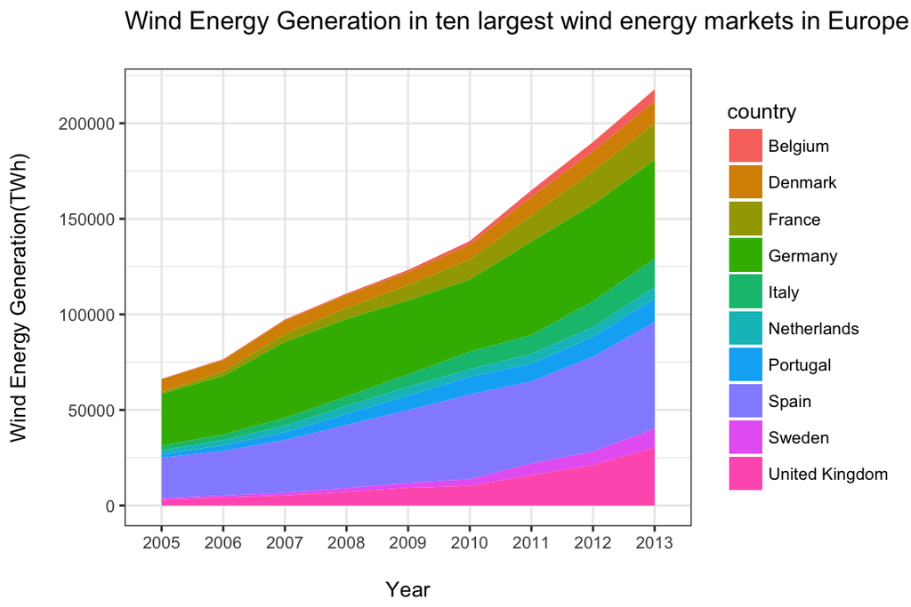

## Trends in Solar Electricity Generation

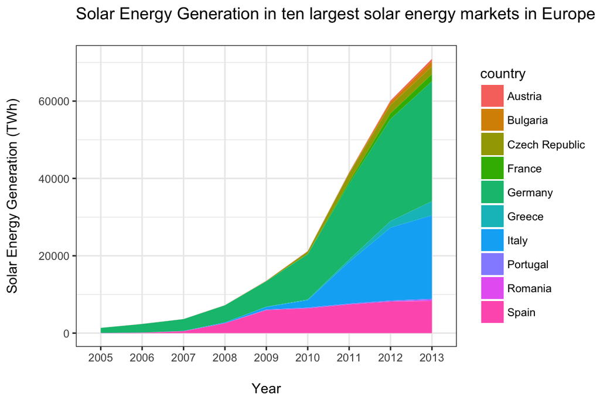

- Meteoric growth in solar energy generation
- Largest markets for solar energy are Germany, Spain and Italy

## Our Research Question

**What are the determinants of renewable energy in EU countries?**  
.  
We try to answer this question using data for 28 EU-countries (2005-2013). Our data was sourced from Eurostat, The World Bank and OPEC and is also available on our GitHub repository.

## Our Analysis

### Dependent Variable:

Percentage of total energy consumption coming from solar and wind (sw pc elec)

### Independent variables:

- GDP per Capita ('000 USD)
- Net Energy Imports as a percentage of total energy consumption (%)
- Number of patents filed in RE technologies
- Long-term interest rates (%, 10 Year Bond Yield)
- Crude oil prices (USD)

## Model

- We estimate the model: \(sw pc elec = \alpha + \beta1*GDP capita + \beta2*net energy imports\)  
  \(+ \beta3*interest rates + \beta4*oil_price + \beta5*patents\)
- Different model specifications: pooled ordinary least squares, fixed effects model, random effects model
- The Hausman test indicates presence of panel specific effects

## Regression results

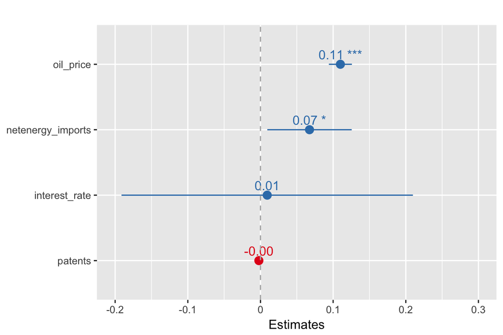

## Effect of Oil Prices

#### Marginal Effect of Oil Price Conditioned Over Import Intensity of Energy

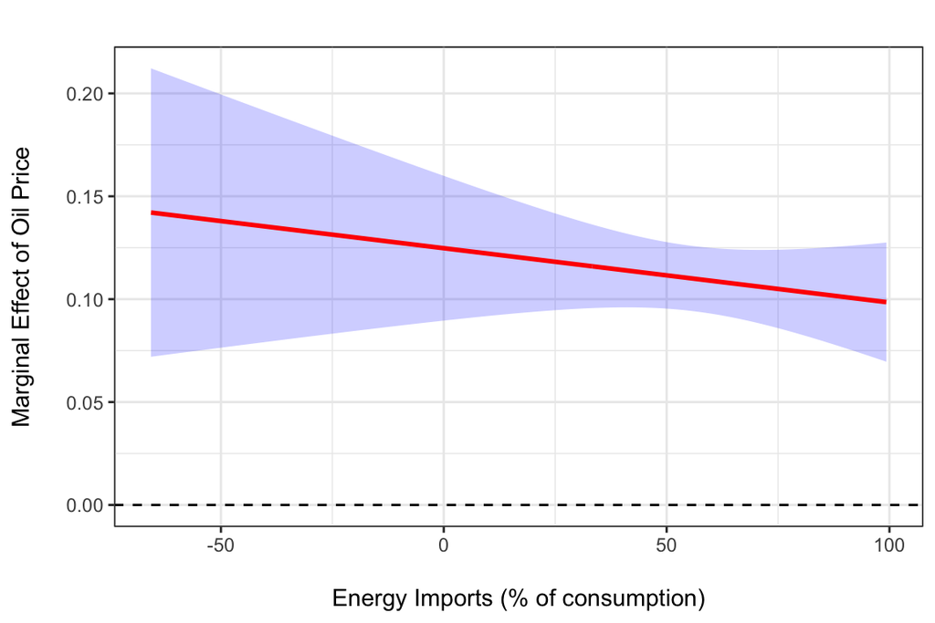

## Country Specific Effects

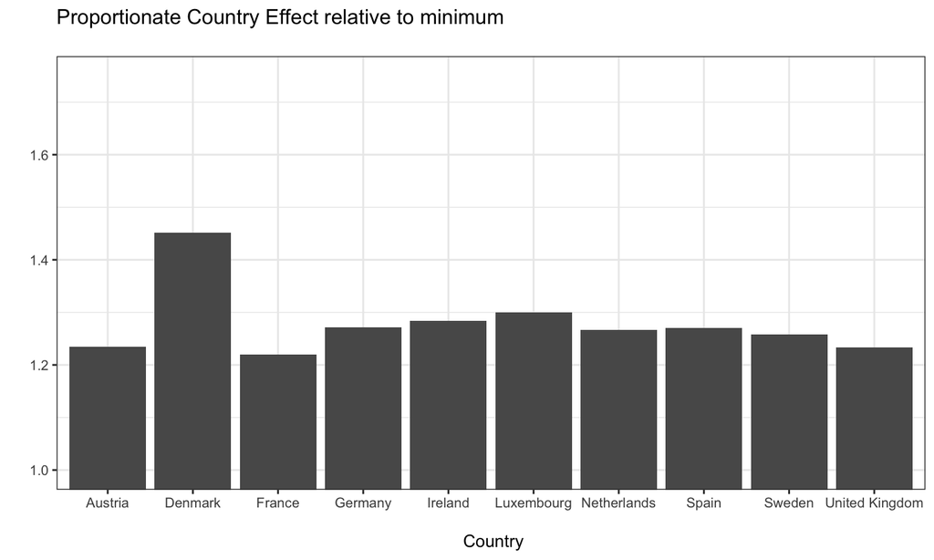

Country specific effects are statistically significant

## Overall Results and Conclusion

- Renewable energy uptake varies significantly across EU countries
- The increase in cost of conventional energy seems to be an important factor in explaining RE development
- Country specific conditions including renewable energy development policy, geography plays an important role
- Next steps: disentangle the effect of policy from country specific effects